# Biz2Credit

NehaBora

August 4, 2017

### Exercises

1. Count the number of users, bank accounts and tabulate:
1. the number of bank accounts for each user
2. the number of months of each bank account for which data is available
3. the total number of credits (deposits), debits (withdrawals) and their averages per month for each bank account and each customer
4. the total dollar value of credits, debits and their averages per month for each bank account and each customer
2. Consider userid: 219154, bank_account_id: 4614 - plot the withdrawals, deposits and daily balance as a daily time series; do the same for userid: 217867, bank_account_id : 5420.
3. For the customers with the above userids, plot the withdrawals, deposits and daily balance as a daily time series (aggregate over all their bank accounts)
4. Find a way to classify debit and credit transactions into a manageable set of sub-categories based on the description of the transaction. What % of each customer’s debit and credit transactions fall within the sub-categories that you have defined?
5. The cash flow of a business has many dimensions [for example, top 5 deposits/Total deposits, average # of days between two withdrawals, coefficient of variation of the daily balance] that are potentially relevant to a borrower’s ability to repay. Can you obtain the value of these variables for each customer? What other cash flow variables can you hypothesize that could be relevant for predicting customer default?

```r
setwd('D:/Challenges')
df <- read.csv('Biz2Credit_Challenge.csv', header = TRUE)
df <- df[,1:10]
```

```r
#Solutions_Q1 <- createWorkbook()

suppressPackageStartupMessages(library(dplyr))
suppressPackageStartupMessages(library(tidyr))

userall = n_distinct(df$userid)
bankacc_all = n_distinct(df$bank_account_id)

q11 <- df %>% group_by(userid) %>% summarize(number_of_bank_accounts = n_distinct(bank_account_id))
library(xlsx)
#addWorksheet(Solutions_Q1, "q11")
#writeData(Solutions_Q1, 1, q11)
#write.xlsx(q11, file = "Solutions_Q1.xlsx",sheetName = "q11")
```

```r
df$post_date <- as.character(df$post_date)
#df <- df strsplit(post_date)
df <- separate(data = df, col = post_date, into = c("post_date", "post_date_time"), sep = "\\ ")
df$post_date <- as.POSIXlt(strptime(df$post_date, "%d-%m-%y"))
df$date_ym <-substr(df$post_date,0,7)
df$post_date <- as.Date(df$post_date)
```

2. the number of months of each bank account for which data is available

```r
q12 <- df %>% group_by(bank_account_id) %>% summarize(number_months_bankacnt = n_distinct(date_ym))
#addWorksheet(Solutions_Q1, "q12")
#writeData(Solutions_Q1, 2, q12)
#write.xlsx(q12, file = "Solutions_Q1.xlsx",sheetName = "q12")
```

3. the total number of credits (deposits), debits (withdrawals) and their averages per month for each bank account and each customer

```r
suppressPackageStartupMessages(library(data.table))
q13 <- df%>% group_by(bank_account_id,userid) %>% summarize(totalnum_credit = table(transaction_type)[1], totalnum_debit = table(transaction_type)[2], avgnum_credit = table(transaction_type)[1]/(uniqueN(date_ym[ transaction_type == 'credit'])), avgnum_debit = table(transaction_type)[2]/(uniqueN(date_ym[ transaction_type == 'debit'])))

#addWorksheet(Solutions_Q1, "q13")
#writeData(Solutions_Q1, 3, q13)

#write.xlsx(as.data.frame(q13), file = "Solutions_Q1.xlsx",sheetName = "q13")
```

4. the total dollar value of credits, debits and their averages per month for each bank account and each customer

```r
q14 <- df%>% group_by(bank_account_id,userid) %>% summarize(total_value_credit = sum(amount[transaction_type == 'credit']), total_value_debit = sum(amount[transaction_type == 'debit']),avgvalue_credit = sum(amount[transaction_type == 'credit'])/(uniqueN(date_ym[ transaction_type == 'credit'])), avgvalue_debit = sum(amount[transaction_type == 'debit'])/(uniqueN(date_ym[ transaction_type == 'debit'])))

#addWorksheet(Solutions_Q1, "q14")
#writeData(Solutions_Q1, 4, q14)

#write.xlsx(as.data.frame(q14), file = "Solutions_Q1.xlsx",sheetName = "q14")

#saveWorkbook(Solutions_Q1, file = "Solutions_Q1.xlsx", overwrite = TRUE)
```

2. Consider userid: 219154, bank_account_id: 4614 - plot the withdrawals, deposits and daily balance as a daily time series; do the same for userid: 217867, bank_account_id : 5420.

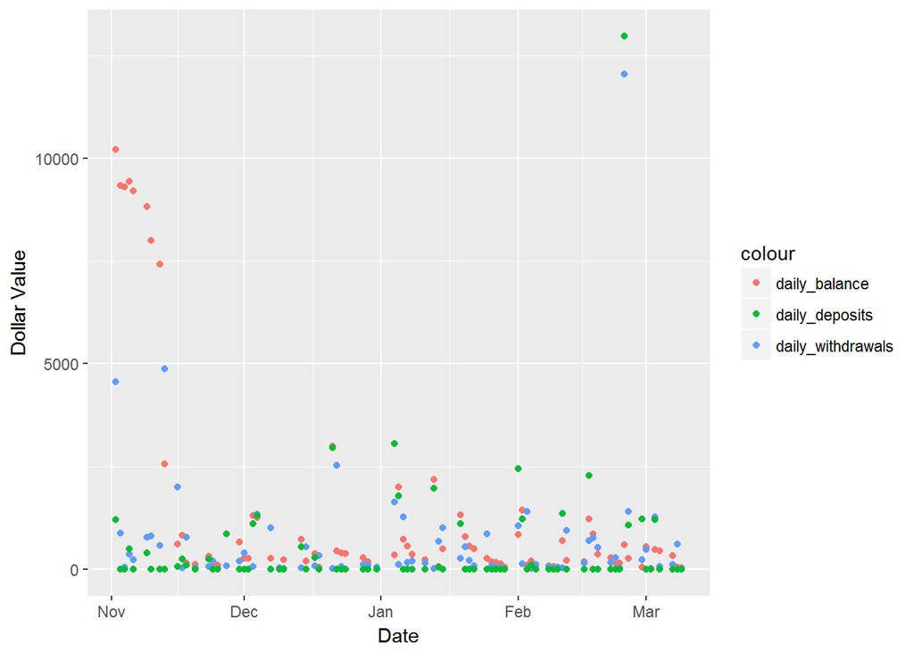

```r
Solutions_Q2_Q3 <- createWorkbook()
df2_sub1 <- df %>% filter(userid == 219154,bank_account_id == 4614)
ts1 <- df2_sub1 %>% group_by(post_date) %>% summarize(daily_balance = running_balance[trans_order == max(trans_order)],daily_withdrawals = sum(amount[transaction_type == 'debit']), daily_deposits = sum(amount[transaction_type == 'credit']), daily_turnarnd = -sum(amount[transaction_type == 'debit']) + sum(amount[transaction_type == 'credit']) )

suppressPackageStartupMessages(library(ggplot2))
ts1 %>% filter(post_date >= '2001-01-01')%>% ggplot(aes(x = post_date)) + geom_point(aes(y = daily_balance,color = 'daily_balance')) + xlab("Date") + ylab("Dollar Value") +geom_point(aes(y = daily_withdrawals, color = 'daily_withdrawals'))+ geom_point(aes(y = daily_deposits, color = 'daily_deposits'))
```

```r
#addWorksheet(Solutions_Q2_Q3, "q21_userid219154_bnkaccid4614")
#writeData(Solutions_Q2_Q3, 1,as.data.frame(ts1) )
#write.xlsx(as.data.frame(ts1), file = "Solutions_Q2_Q3.xlsx",sheetName = "q21_userid219154_bnkaccid4614")
# p1 <- ts1 %>% filter(post_date >= '2001-01-01', daily_balance <= 5000)%>% ggplot(aes(x = post_date)) + geom_point(aes(y = daily_balance,color = 'daily_balance')) + geom_line(aes(y = daily_balance,color = 'daily_balance')) + xlab("Date") + ylab("Dollar Value")
# p2 <- ts1 %>% filter(post_date >= '2001-01-01')%>% ggplot(aes(x = post_date)) +geom_point(aes(y = daily_withdrawals, color = 'daily_withdrawals'))+ xlab("Date") + ylab("Dollar Value")
# p3 <- ts1 %>% filter(post_date >= '2001-01-01')%>% ggplot(aes(x = post_date)) +geom_point(aes(y = daily_deposits, color = 'daily_deposits'))+ xlab("Date") + ylab("Dollar Value")
# p4 <- ts1 %>% filter(post_date >= '2001-01-01', daily_balance <= 5000, daily_withdrawals <= 5000)%>% ggplot(aes(x = post_date)) + geom_point(aes(y = daily_balance,color = 'daily_balance')) + xlab("Date") + ylab("Dollar Value") +geom_point(aes(y = daily_withdrawals, color = 'daily_withdrawals'))+ geom_point(aes(y = daily_deposits, color = 'daily_deposits'))
# multiplot(p1,p2,p3,p4,cols = 2)
```

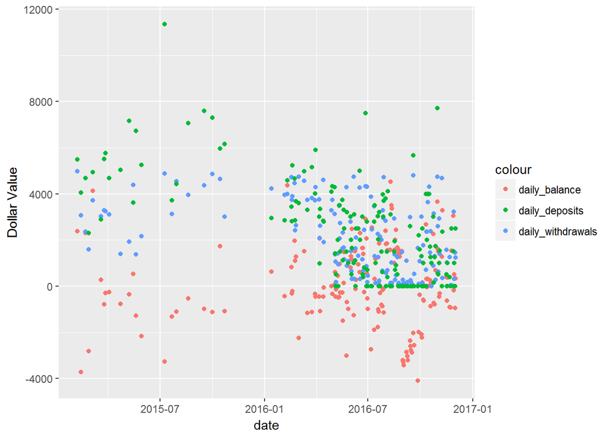

```r
df2_sub2 <- df %>% filter(userid == 217867,bank_account_id == 5420)
ts2 <- df2_sub2 %>% group_by(post_date) %>% summarize(daily_balance = running_balance[trans_order == max(trans_order)],daily_withdrawals = sum(amount[transaction_type == 'debit']), daily_deposits = sum(amount[transaction_type == 'credit']), daily_turnarnd = -sum(amount[transaction_type == 'debit']) + sum(amount[transaction_type == 'credit']) )

#addWorksheet(Solutions_Q2_Q3, "q22_userid217867_bnkaccid5420")
#writeData(Solutions_Q2_Q3, 2,as.data.frame(ts2) )

#write.xlsx(as.data.frame(ts2), file = "Solutions_Q2_Q3.xlsx",sheetName = "q22_userid217867_bnkaccid5420")

#suppressPackageStartupMessages(library(ggplot2))
ts2 %>% filter(daily_balance <= 5000, daily_withdrawals <= 5000)%>%ggplot(aes(x = post_date)) + geom_point(aes(y = daily_balance,color = 'daily_balance'))+ xlab("date") + ylab("Dollar Value") + geom_point(aes(y = daily_withdrawals, color = 'daily_withdrawals'))+ geom_point(aes(y = daily_deposits, color = 'daily_deposits'))
```

3. For the customers with the above userids, plot the withdrawals, deposits and daily balance as a daily time series (aggregate over all their bank accounts)

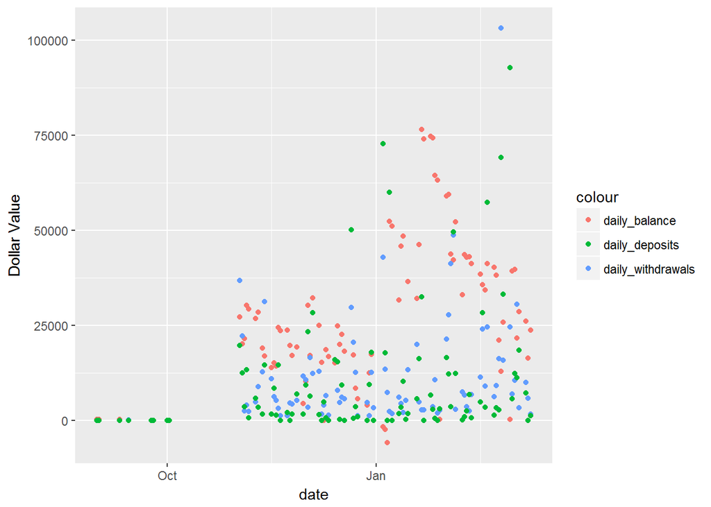

```r
db <- function(bank_account_id,running_balance,trans_order){
y = 0
sum(for ( x in unique(bank_account_id)){y = y + running_balance[bank_account_id == x & trans_order == max(trans_order[bank_account_id== x])]})
return(y)}

df3_sub1 <- df %>% filter(userid == 219154)
ts11 <- df3_sub1 %>% group_by(post_date) %>% summarise(daily_balance = db(bank_account_id,running_balance,trans_order),daily_withdrawals = sum(amount[transaction_type == 'debit']),daily_deposits = sum(amount[transaction_type == 'credit']), daily_turnarnd = -sum(amount[transaction_type == 'debit']) + sum(amount[transaction_type == 'credit']))



#addWorksheet(Solutions_Q2_Q3, "q31_userid219154")
#writeData(Solutions_Q2_Q3, 3,as.data.frame(ts11) )
#write.xlsx(as.data.frame(ts11), file = "Solutions_Q2_Q3.xlsx",sheetName = "q31_userid219154")

ts11 %>%filter(post_date >= '2001-01-01')%>% ggplot(aes(x = post_date)) + geom_point(aes(y = daily_balance,color = 'daily_balance')) + xlab("date") + ylab("Dollar Value") + geom_point(aes(y = daily_withdrawals, color = 'daily_withdrawals'))+ geom_point(aes(y = daily_deposits, color = 'daily_deposits'))
```

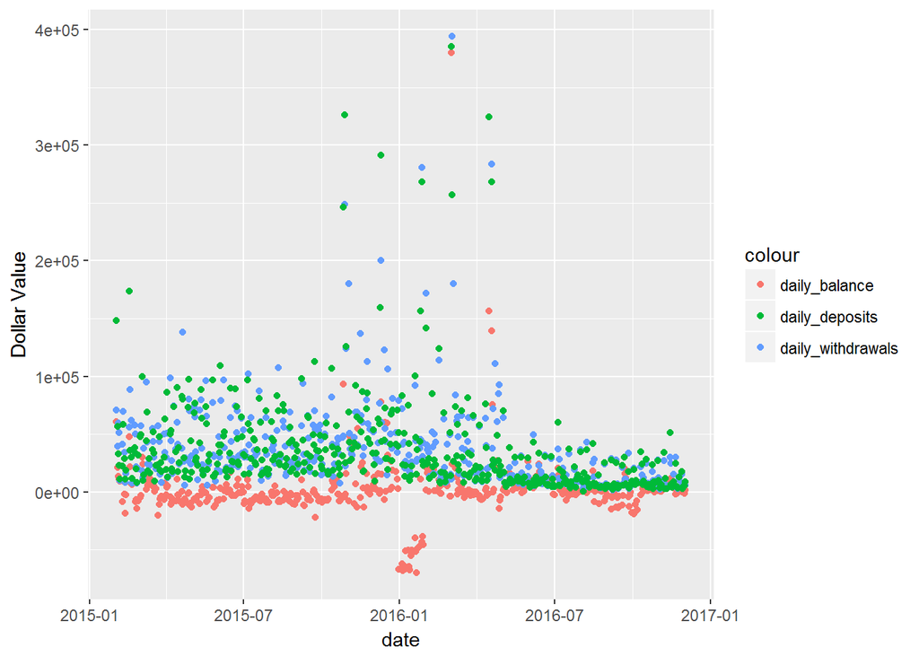

```r
df3_sub2 <- df %>% filter(userid == 217867)
ts21 <- df3_sub2 %>% group_by(post_date) %>% summarise(daily_balance = db(bank_account_id,running_balance,trans_order),daily_withdrawals = sum(amount[transaction_type == 'debit']),daily_deposits = sum(amount[transaction_type == 'credit']), daily_turnarnd = -sum(amount[transaction_type == 'debit']) + sum(amount[transaction_type == 'credit']))

#addWorksheet(Solutions_Q2_Q3, "q32_userid217867")
#writeData(Solutions_Q2_Q3, 4,as.data.frame(ts21) )
#write.xlsx(as.data.frame(ts21), file = "Solutions_Q2_Q3.xlsx",sheetName = "q32_userid217867")

ts21 %>% ggplot(aes(x = post_date)) + geom_point(aes(y = daily_balance,color = 'daily_balance')) + xlab("date") + ylab("Dollar Value")+ geom_point(aes(y = daily_withdrawals, color = 'daily_withdrawals'))+ geom_point(aes(y = daily_deposits, color = 'daily_deposits'))
```

```r
#saveWorkbook(Solutions_Q2_Q3, file = "Solutions_Q2_Q3.xlsx", overwrite = TRUE)
```

4. Find a way to classify debit and credit transactions into a manageable set of sub-categories based on the description of the transaction. What % of each customer’s debit and credit transactions fall within the sub-categories that you have defined?

```r
#making categories
Travel<- "AIRLINE|AIRWAYS|FRONTIER|CHEAPOAIR|AMTRAK|ENTERPRISE|HOTEL|GREYHOUND|MEGABUS|TRAILWAYS|TRAVEL|ROAD|RAIL|BOAT|EXPEDIA|KAYAK|UBER"

Food <- "RESTAURANTS|CAFE|STARBUCKS|COFFEE|MCDONALD'S|TACO|WENDY'S|PIZZA|CHIPOTLE|ICECREAM|JIMMY|SANDWICH|BURGER|BREAD|ARBY|BAGELS|CHICKEN|KFC|CHICK-FIL-A|KITCHEN|IHOP|GRILL|BAR|Restaurant|Thai|Chinese|Indian|DHOOM|DENNY'S|DUNKIN|FOOD|GUARAPO'S|TULSI|Tulsi|ChowNow|PITA|CLEAN JUICE"

Supermarkets <- "TARGET|WAL-MART|WALMART|WALGREENS|COSTCO|TRADER JOE'S|SAMSCLUB|DOLLAR|SUPERCENTER|MART|CVS|HOMEDEPOT.COM|HOME DE|BURLNGTON|KENNETH COLE|CORNER STORE|WHOLEFDS|HARRIS TEETER|SAFEWAY STORE|SHIRAZ MARKET|RESTAURANT DEPOT|TALBOTS|APPLIANCE|GROUPON|AMAZON"

Utilities_Gasoline <- "WATER|ELECTRIC|INTRNT|INTERNET|GAS|UTILITY|SHELL|OIL|FUEL|CHEVRON|EXXON|Energy"

Loan_Insurance <- "Loan|MTG|INSURANCE|INSUR|STATE FARM|GMFINANCIA|PREM|ACCESS INS|HOMELOA|LIFE INS|ELEPHANT INS HENRICO"
#Fees <- "FEES|FEE|INTEREST"

Entertainment <- "CABLE|PERFORMANCE|MUSIC|MOVIES|CINE|SHOW|THEATRE|DIRECTV|Gym|FIT|TV|DISH NETWORK|VERIZON WRLS|Verizon|COMCAST|AT&amp;T|VERIZON|NETFLIX"

Direct_deposit_withdrawal <- "CHECK | Customer withdrawal|ATM|Check|check|WIRE|Wire|wire|WITHDRAWAL|CHECKS "

df$class <- "Other"

Credit_card_pay <- "AMERICAN EXPRESS|CAPITAL ONE|WELLS FARGO|BANK"
################################################################################################################

Wallet <- "VENMO|STRIPE |PAYPAL|SQUARE |BILL PAY|MOBILE PMT|MOBILE DEPOSIT"
Credit_Card <- "VISA DD|CARD|VISA"
Direct <- "CHECK#|CASHED |PAID CHECK|CHECK #|CUSTOMER WITHDRAWAL|CHECK WITH IMAGE|SUBSTITUTE CHECK|CHECKS |ATM|WITHDRAWAL MADE|BANK CHECK OR DRAFT"
ACH <- "ACH"
Payment_tech <- "HRTLAND|HEARTLDP"
Late_Fees <- "OVERDRAFT"
Online <- "ONLINE |INTERNET|WIRE|EDEPOSIT|EWITHDRAWAL"


df$description <-as.character(df$description)
df$description <- sapply(df$description, toupper)
df$class = ifelse(grepl(Direct, df$description), "Direct",
    ifelse(grepl(ACH, df$description), "ACH",
      ifelse(grepl(Online,df$description), "Online",ifelse(grepl(Wallet,df$description), "Wallet",ifelse(grepl(Payment_tech,df$description), "Payment_tech",ifelse(grepl(Late_Fees,df$description), "Late_Fees",ifelse(grepl(Credit_Card,df$description), "Credit_Card","Other")))))))

df_other <- df %>% filter(class == 'Other')
```

What % of each customer’s debit and credit transactions fall within the sub-categories that you have defined?

```r
#Solutions_Q4_Q5 <- createWorkbook()
q4 <- df %>% group_by(userid,transaction_type) %>% summarize(ach = table(class)[1]/n(),cc = table(class)[2]/n(),direct = table(class)[3]/n(),latefees = table(class)[4]/n(),online_transfers = table(class)[5]/n(),other = table(class)[6]/n(),paymenttechs = table(class)[7]/n(),Wallet = table(class)[8]/n())
#addWorksheet(Solutions_Q4_Q5, "q4")
#writeData(Solutions_Q4_Q5, 1,as.data.frame(q4) )
```

5. The cash flow of a business has many dimensions [for example, top 5 deposits/Total deposits, average # of days between two withdrawals, coefficient of variation (std/ mean)of the daily balance] that are potentially relevant to a borrower’s ability to repay. Can you obtain the value of these variables for each customer? What other cash flow variables can you hypothesize that could be relevant for predicting customer default?

```r
#Debit/Credit Ratio

zz <- data.frame(matrix(ncol = 1, nrow = n_distinct(df$userid)))
duserid <- unique(df$userid)
for(i in 1:nrow(zz)){
  #z1= data.frame(matrix(ncol = 2, nrow = n_distinct(df$userid)))
  #colnames(z1) <- c('daily_withdrawals','daily_deposits')
  df_user <- df %>% filter(userid == duserid[i])
  tsz <- df_user %>% group_by(post_date) %>% summarise(daily_withdrawals = sum(amount[transaction_type == 'debit']),daily_deposits = sum(amount[transaction_type == 'credit']))
  zz[i,1]= sum(tsz$daily_withdrawals, na.rm  = TRUE)/sum(tsz$daily_deposits, na.rm  = TRUE)
}
colnames(zz) <- ''
```

```r
q5 <- df %>% group_by(userid) %>% summarize(top5 = sum(sort(amount[transaction_type == 'credit'],decreasing = TRUE)[1:5])/sum(amount[transaction_type == 'credit']),  avgdays_btn_withdrawals = mean(as.numeric(difftime(post_date[transaction_type == 'debit'], lag(post_date[transaction_type == 'debit'],1),units= 'days')),na.rm = TRUE))

#Coefficient of Variation
z= data.frame(matrix(ncol = 1, nrow = n_distinct(df$userid)))
duserid <- unique(df$userid)
for(i in 1:nrow(z)){
  df_user <- df %>% filter(userid == duserid[i])
  ts <- df_user %>% group_by(post_date) %>% summarise(daily_balance = db(bank_account_id,running_balance,trans_order))
  z[i,1] = sd(ts$daily_balance)/mean(ts$daily_balance)
}
colnames(z) <- ''
q5$Coeff_Variation <- z
q5$debitcredit_ratio <- zz
q5 <- as.data.frame(q5)
#addWorksheet(Solutions_Q4_Q5, "q5")
#writeData(Solutions_Q4_Q5,2,q5)
#saveWorkbook(Solutions_Q4_Q5, file = "Solutions_Q4_Q5.xlsx", overwrite = TRUE)
#write.csv(q5, 'q5.csv')
```

```r
# Multiple plot function
#
# ggplot objects can be passed in ..., or to plotlist (as a list of ggplot objects)
# - cols:   Number of columns in layout
# - layout: A matrix specifying the layout. If present, 'cols' is ignored.
#
# If the layout is something like matrix(c(1,2,3,3), nrow=2, byrow=TRUE),
# then plot 1 will go in the upper left, 2 will go in the upper right, and
# 3 will go all the way across the bottom.
#
multiplot <- function(..., plotlist=NULL, file, cols=1, layout=NULL) {
  library(grid)

  # Make a list from the ... arguments and plotlist
  plots <- c(list(...), plotlist)

  numPlots = length(plots)

  # If layout is NULL, then use 'cols' to determine layout
  if (is.null(layout)) {
    # Make the panel
    # ncol: Number of columns of plots
    # nrow: Number of rows needed, calculated from # of cols
    layout <- matrix(seq(1, cols * ceiling(numPlots/cols)),
                    ncol = cols, nrow = ceiling(numPlots/cols))
  }

 if (numPlots==1) {
    print(plots[[1]])

  } else {
    # Set up the page
    grid.newpage()
    pushViewport(viewport(layout = grid.layout(nrow(layout), ncol(layout))))

    # Make each plot, in the correct location
    for (i in 1:numPlots) {
      # Get the i,j matrix positions of the regions that contain this subplot
      matchidx <- as.data.frame(which(layout == i, arr.ind = TRUE))

      print(plots[[i]], vp = viewport(layout.pos.row = matchidx$row,
                                      layout.pos.col = matchidx$col))
    }
  }
}
```